# Discussion 3.1: Applying Time Series Models to Project Dataset

U.S. Retail Sales: Clothing & Clothing Accessories Stores (MRTSSM448USN)

Jordan Blackman

2026-11-02

# Executive Summary

This document performs the individual modeling contribution for **Discussion 3.1: Applying the Time Series Models to Your Project Dataset**.

Following our team project consensus to focus on U.S. Retail Trade (Census Bureau MRTS), and in coordination with my teammate Ramin (who modeled Health & Personal Care Stores using ETS and TSLM), I analyze **U.S. Retail Sales: Clothing and Clothing Accessories Stores (`MRTSSM448USN`)** to evaluate **Seasonal ARIMA (SARIMA)** modeling.

We strictly execute the **7-Step Box-Jenkins / FPP3 ARIMA Modelling Procedure** taught in Module 3: 1. **Plot the data & identify patterns/shocks.** 2. **Transform the data (Log / Box-Cox) to stabilize seasonal variance.** 3. **Difference the data until stationary (KPSS and seasonal unit-root tests).** 4. **Plot ACF/PACF of differenced data to determine candidate manual models.** 5. **Estimate manual and automated models and compare $\text{AIC}_c$.** 6. **Conduct residual diagnostics (ACF of residuals & Ljung-Box Portmanteau white noise tests) and iterate if residuals are not white noise.** 7. **Calculate out-of-sample forecasts over a 12-month holdout test set.**

# 1. Environment & Data Ingestion

```r
library(tidyverse)
library(fpp3)
library(scales)
```

We pull the official monthly retail sales data for **Clothing and Clothing Accessories Stores (NAICS 448)** directly from the **Federal Reserve Bank of St. Louis (FRED)**:

```r
# Ingest directly from FRED via curl wrapper
url <- "https://fred.stlouisfed.org/graph/fredgraph.csv?id=MRTSSM448USN"
cmd <- sprintf('curl -sL "%s"', url)
raw_lines <- system(cmd, intern = TRUE)
df <- read.csv(text = raw_lines, stringsAsFactors = FALSE)
names(df) <- c("date", "sales")

# Construct monthly tsibble (converting sales to Billions USD)
apparel_ts <- df |>
  mutate(
    date = as.Date(date),
    Month = yearmonth(date),
    sales_billions = as.numeric(sales) / 1000
  ) |>
  filter(!is.na(sales_billions)) |>
  as_tsibble(index = Month)

# Cache locally for team reproducibility
data_dir <- "data"
if (!dir.exists(data_dir)) dir.create(data_dir, recursive = TRUE)
write_csv(apparel_ts, file.path(data_dir, "clothing_accessories_sales_monthly.csv"))

# Summary view
glimpse(apparel_ts)
```

```
## Rows: 416
## Columns: 4
## $ date           <date> 1992-01-01, 1992-02-01, 1992-03-01, 1992-04-01, 1992-0…
## $ sales          <int> 6734, 7302, 8245, 9152, 9294, 8930, 8846, 10226, 9311, …
## $ Month          <mth> 1992 Jan, 1992 Feb, 1992 Mar, 1992 Apr, 1992 May, 1992 …
## $ sales_billions <dbl> 6.734, 7.302, 8.245, 9.152, 9.294, 8.930, 8.846, 10.226…
```

# 2. Step 1 & Step 2: Plot the Data & Variance Stabilization Transformation

## Step 1: Initial Plot & Component Inspection

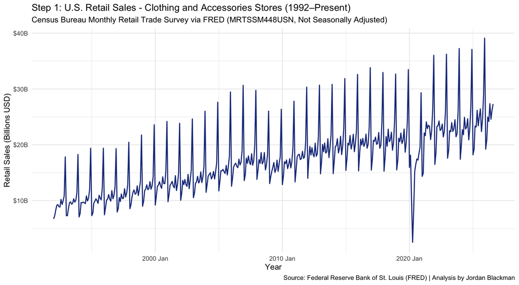

```r
ggplot(apparel_ts, aes(x = Month, y = sales_billions)) +
  geom_line(color = "#1e3a8a", linewidth = 0.7) +
  scale_y_continuous(labels = dollar_format(suffix = "B")) +
  labs(
    title = "Step 1: U.S. Retail Sales - Clothing and Accessories Stores (1992–Present)",
    subtitle = "Census Bureau Monthly Retail Trade Survey via FRED (MRTSSM448USN, Not Seasonally Adjusted)",
    caption = "Source: Federal Reserve Bank of St. Louis (FRED) | Analysis by Jordan Blackman",
    y = "Retail Sales (Billions USD)",
    x = "Year"
  ) +
  theme_minimal(base_size = 11)
```

- **Patterns Identified:**
  - **Upward Secular Growth:** Sales expand from ~$6.7B in 1992 to >$27B in 2026.
  - **Extreme Annual Seasonality ($s = 12$):** Explosive December holiday surge (often $+50\%$ to $+60\%$ over annual baseline), with secondary back-to-school lifts in August.
  - **Severe Economic Shocks:** Large drops during the 2008 Great Financial Crisis and a historic collapse in March–April 2020 due to physical retail lockdown mandates.

## Step 2: Variance Stabilization (Box-Cox / Natural Log)

Notice that as sales levels grow, the vertical spread of the December peak widens proportionally (multiplicative seasonality / heteroscedasticity).

```r
# Compute Guerrero's optimal Box-Cox lambda
lambda_guerrero <- apparel_ts |>
  features(sales_billions, features = guerrero) |>
  pull(lambda_guerrero)

cat("Guerrero optimal Box-Cox lambda:", round(lambda_guerrero, 4), "\n")
```

```
## Guerrero optimal Box-Cox lambda: 0.4235
```